# Assignment 4

# scatterplot of heart rates

# with toggle for certain activities:

# violin plot of heart rates

# 3D map of terrain (lat x long x alt) vs heart rate as color bar

Other ideas:

# activity vs enhanced_speed

# activity vs change in enhanced_altitude

# speed vs heart_rate for certain activities

# for the same distance, has there been a change in heart_rate over time?

```python
# Rule 1: Tell a story for an audience
# Rule 2: Document the process, not just the results
# Rule 3: Use cell divisions to make steps clear
# Rule 4: Modularize code- wrap code you are about to copy and reuse in a function
# Rule 5: Record dependencies- Listing the versions of critical dependencies in the notebook itself (best done at the bottom) will ensure that, if used in isolation from its environment, the notebook still contains critical information to help readers run it.
# Rule 6: Use version control- since notebooks contain code and code inevitably contains bugs, being able to determine the history of when a given bug you have discovered was introduced to the code versus when it was fixed—and thus what analyses it may have affected—is a key capability in scientific computation
# Rule 7: Build a pipeline- a well-designed notebook can be generalized into a pipeline that easily repeats that analysis using different input data and parameters. With this end in mind, design your notebook from the beginning to allow such future repurposing. Place key variable declarations, especially those that will be changed when doing a new analysis, at the top of the notebook rather than burying them somewhere in the middle. Perform preparatory steps, like data cleaning, directly in the notebook and avoid manual interventions.
# Rule 8: Share and explain your data- Ideally, you will share your entire data set alongside your notebooks. We realize many data sets are too large or too sensitive to share this way. In these cases, consider breaking down large and complex data sets into tiers such that, even if the raw data are prohibitively large to include alongside your published notebooks or are constrained by privacy or other access issues, reproducibility and interpretability isn’t lost. You can host public copies of medium-sized, anonymized data in a variety of hosting services (for example, figshare [https://figshare.com/], zenodo [https://zenodo.org/]), and include further processed data sets alongside the notebooks in the final repository. To uniquely and permanently identify data sets, these hosting services provide Digital Object Identifiers (dois). This tiered approach both provides public confidence and allows others to reproduce and reuse the latter stages of an analysis even without access to the full, raw data set.
# Rule 9: Design your notebooks to be read, run, and explored
# Rule 10: Advocate for open research

# from: https://journals.plos.org/ploscompbiol/article?id=10.1371/journal.pcbi.1007007
```

Rule 1: Tell a Story for an Audience (with heading)

Rule 9: Design your notebooks to be read, run, and explored. This notebook has been designed to be read, run and explored.

Rule 10: Advocate for open research. I encourage you to take a look at this data and draw your own conclusions!

Rule 2: Document the process, not just the results.

Here are the packages we will import to process the data.

```python
import pandas as pd
import numpy as np
import matplotlib as mpl
import matplotlib.pyplot as plt
import plotly.express as px
```

Rule 3: Use cell divisions to make steps clear

Here, we will load in the data from the fitness tracking devices.

```python
df=pd.read_csv("strava.csv")
pd.set_option('display.max_columns', None)
df.head()
```

|  | Air Power | Cadence | Form Power | Ground Time | Leg Spring Stiffness | Power | Vertical Oscillation | altitude | cadence | datafile | distance | enhanced_altitude | enhanced_speed | fractional_cadence | heart_rate | position_lat | position_long | speed | timestamp | unknown_87 | unknown_88 | unknown_90 |
| --- | --- | --- | --- | --- | --- | --- | --- | --- | --- | --- | --- | --- | --- | --- | --- | --- | --- | --- | --- | --- | --- | --- |
| 0 | NaN | NaN | NaN | NaN | NaN | NaN | NaN | NaN | 0.0 | activities/2675855419.fit.gz | 0.00 | NaN | 0.000 | 0.0 | 68.0 | NaN | NaN | 0.0 | 2019-07-08 21:04:03 | 0.0 | 300.0 | NaN |
| 1 | NaN | NaN | NaN | NaN | NaN | NaN | NaN | NaN | 0.0 | activities/2675855419.fit.gz | 0.00 | NaN | 0.000 | 0.0 | 68.0 | NaN | NaN | 0.0 | 2019-07-08 21:04:04 | 0.0 | 300.0 | NaN |
| 2 | NaN | NaN | NaN | NaN | NaN | NaN | NaN | NaN | 54.0 | activities/2675855419.fit.gz | 1.32 | NaN | 1.316 | 0.0 | 71.0 | NaN | NaN | 1316.0 | 2019-07-08 21:04:07 | 0.0 | 300.0 | NaN |
| 3 | NaN | NaN | NaN | NaN | NaN | NaN | NaN | 3747.0 | 77.0 | activities/2675855419.fit.gz | 12.19 | 249.4 | 1.866 | 0.0 | 77.0 | 504432050.0 | -999063637.0 | 1866.0 | 2019-07-08 21:04:14 | 0.0 | 100.0 | NaN |
| 4 | NaN | NaN | NaN | NaN | NaN | NaN | NaN | 3798.0 | 77.0 | activities/2675855419.fit.gz | 14.08 | 259.6 | 1.894 | 0.0 | 80.0 | 504432492.0 | -999064534.0 | 1894.0 | 2019-07-08 21:04:15 | 0.0 | 100.0 | NaN |

Now let's take a look at the columns to get a feel for the kind of information we can look at.

```python
print(df.columns)
```

```
Index(['Air Power', 'Cadence', 'Form Power', 'Ground Time',
       'Leg Spring Stiffness', 'Power', 'Vertical Oscillation', 'altitude',
       'cadence', 'datafile', 'distance', 'enhanced_altitude',
       'enhanced_speed', 'fractional_cadence', 'heart_rate', 'position_lat',
       'position_long', 'speed', 'timestamp', 'unknown_87', 'unknown_88',
       'unknown_90'],
      dtype='object')
```

Rule 4: Modularize code- wrap code you are about to copy and reuse in a function

Here we will make a summary of the information in the columns. This tells us which columns we have consistent information from, and which we do not. There are 0 missing records for the datafile column, and there are 64 unique records. There is a timestamp for every row, as well as a distance.

```python
def summarize_dataframe(df):
    """
    Generate a summary of each column in a DataFrame, including:
    - Data type
    - Number of missing values
    - Number of unique values
    """
    summary = {
        col: {
            'Type': df[col].dtype,
            'Missing': df[col].isnull().sum(),
            'Unique': df[col].nunique()
        }
        for col in df.columns
    }

    return pd.DataFrame(summary).T


# Example usage:
summary_df = summarize_dataframe(df)
print(summary_df)
```

```
                         Type Missing Unique
Air Power             float64   22807     40
Cadence               float64   22802     43
Form Power            float64   22807     82
Ground Time           float64   22802    211
Leg Spring Stiffness  float64   22807     83
Power                 float64   22802    306
Vertical Oscillation  float64   22802     54
altitude              float64   25744    688
cadence               float64      22    112
datafile               object       0     64
distance              float64       0  39062
enhanced_altitude     float64      51    733
enhanced_speed        float64      10   1241
fractional_cadence    float64      22      2
heart_rate            float64    2294    127
position_lat          float64     192  36988
position_long         float64     192  38448
speed                 float64   25721    365
timestamp              object       0  40649
unknown_87            float64      22      1
unknown_88            float64    2294      2
unknown_90            float64   22031     20
```

```python
def split_into_activities(df, time_col="timestamp", gap_minutes=10):
    df = df.sort_values(time_col).copy()
    df[time_col] = pd.to_datetime(df[time_col])
    df["time_diff"] = df[time_col].diff()
    activity_gap = pd.Timedelta(minutes=gap_minutes)
    df["new_activity"] = df["time_diff"] > activity_gap
    df["activity_id"] = df["new_activity"].cumsum() + 1
    return df

df = split_into_activities(df)

print(df.head())
```

```
   Air Power  Cadence  Form Power  Ground Time  Leg Spring Stiffness  Power  \
0        NaN      NaN         NaN          NaN                   NaN    NaN
1        NaN      NaN         NaN          NaN                   NaN    NaN
2        NaN      NaN         NaN          NaN                   NaN    NaN
3        NaN      NaN         NaN          NaN                   NaN    NaN
4        NaN      NaN         NaN          NaN                   NaN    NaN

   Vertical Oscillation  altitude  cadence                      datafile  \
0                   NaN       NaN      0.0  activities/2675855419.fit.gz
1                   NaN       NaN      0.0  activities/2675855419.fit.gz
2                   NaN       NaN     54.0  activities/2675855419.fit.gz
3                   NaN    3747.0     77.0  activities/2675855419.fit.gz
4                   NaN    3798.0     77.0  activities/2675855419.fit.gz

   distance  enhanced_altitude  enhanced_speed  fractional_cadence  \
```

[output cut: 26 more lines]

This part computes the average speed for each activity_id, and then classifies an activity as walking, running or cycling based on the average speed in meters per second. It then adds an activity_type and avg_speed_m_s column to the original dataframe.

```python
# --- Compute average speed per activity_id ---
avg_speed_df = df.groupby('activity_id')['enhanced_speed'].mean().reset_index(name="avg_speed_m_s")
avg_speed_df = avg_speed_df.rename(columns={'enhanced_speed': 'avg_speed_m_s'})

if "avg_speed_m_s" in df.columns:
    df = df.drop(columns=["avg_speed_m_s"])

# --- Merge avg_speed_m_s back into original DataFrame ---
df = df.merge(avg_speed_df, on='activity_id', how='left')

# --- Classify activity type based on avg_speed_m_s ---
def classify_activity_type(avg_speed_m_s):
    if avg_speed_m_s < 2.0:
        return "Walking"
    elif avg_speed_m_s < 5.0:
        return "Running"
    elif avg_speed_m_s >= 5.0:
        return "Cycling"
    else:
        return "Other"

df['activity_type'] = df['avg_speed_m_s'].apply(classify_activity_type)


# --- 5️⃣ Optional: check results ---
print(df[['activity_id', 'speed', 'avg_speed_m_s', 'activity_type']].head(10))
```

```
   activity_id   speed  avg_speed_m_s activity_type
0            1     0.0       2.088154       Running
1            1     0.0       2.088154       Running
2            1  1316.0       2.088154       Running
3            1  1866.0       2.088154       Running
4            1  1894.0       2.088154       Running
5            1  1894.0       2.088154       Running
6            1  1903.0       2.088154       Running
7            1  1997.0       2.088154       Running
8            1  2025.0       2.088154       Running
9            1  2006.0       2.088154       Running
```

```python
def add_avg_speed_and_activity_type(df, speed_col='enhanced_speed', activity_col='activity_id'):
    """
    Adds 'avg_speed_m_s' and 'activity_type' columns to the original DataFrame.
    Each activity_id gets a single avg_speed and activity_type assigned to all its rows.

    Parameters:
    - df: pandas DataFrame with speed and activity_id columns
    - speed_col: name of the speed column (default 'enhanced_speed')
    - activity_col: name of the activity ID column (default 'activity_id')

    Returns:
    - df: original DataFrame with new columns added
    - summary_df: DataFrame showing each activity_id with avg_speed_m_s and activity_type
    """
    import pandas as pd

    #Compute average speed per activity_id
    avg_speed_df = (
        df.groupby(activity_col)[speed_col]
        .mean()
        .reset_index()
        .rename(columns={speed_col: 'avg_speed_m_s'})
    )

    #Define activity type classification
    def classify_activity_type(avg_speed_m_s):
        if avg_speed_m_s < 2.0:
            return "Walking"
        elif avg_speed_m_s < 5.0:
            return "Running"
        elif avg_speed_m_s >= 5.0:
            return "Cycling"
        else:
            return "Other"

    avg_speed_df['activity_type'] = avg_speed_df['avg_speed_m_s'].apply(classify_activity_type)

    # 3️⃣ Drop old columns if they exist to avoid merge conflicts
    df = df.drop(columns=['avg_speed_m_s', 'activity_type'], errors='ignore')

    # 4️⃣ Merge back to original DataFrame
    df = df.merge(avg_speed_df[[activity_col, 'avg_speed_m_s', 'activity_type']],
                  on=activity_col, how='left')

    return df, summary_df

print(df.head())
print(avg_speed_df.head())
```

```
   Air Power  Cadence  Form Power  Ground Time  Leg Spring Stiffness  Power  \
0        NaN      NaN         NaN          NaN                   NaN    NaN
1        NaN      NaN         NaN          NaN                   NaN    NaN
2        NaN      NaN         NaN          NaN                   NaN    NaN
3        NaN      NaN         NaN          NaN                   NaN    NaN
4        NaN      NaN         NaN          NaN                   NaN    NaN

   Vertical Oscillation  altitude  cadence                      datafile  \
0                   NaN       NaN      0.0  activities/2675855419.fit.gz
1                   NaN       NaN      0.0  activities/2675855419.fit.gz
2                   NaN       NaN     54.0  activities/2675855419.fit.gz
3                   NaN    3747.0     77.0  activities/2675855419.fit.gz
4                   NaN    3798.0     77.0  activities/2675855419.fit.gz

   distance  enhanced_altitude  enhanced_speed  fractional_cadence  \
```

[output cut: 32 more lines]

Turns the raw data into lat and long positions that we can use and compute with.

```python
def clean_gps_data(
    df,
    lat_col="position_lat",
    lon_col="position_long",
    alt_col="enhanced_altitude"
):
    """
    Cleans and converts GPS data:
    - Drops rows with missing GPS
    - Converts Garmin semicircles → degrees (float precision)
    - Converts altitude → integer

    Creates new columns:
        position_lat_degrees
        position_long_degrees
        enhanced_alt_int
    """

    df = df.copy()

    # Drop missing GPS coordinates
    df = df.dropna(subset=[lat_col, lon_col])

    # Convert semicircles → degrees (KEEP FLOAT!)
    factor = 180 / (2**31)
    df["position_lat_degrees"] = df[lat_col] * factor
    df["position_long_degrees"] = df[lon_col] * factor

    # Clean altitude
    df["enhanced_alt_int"] = df[alt_col].round().astype(int)

    return df
```

This part finds the Haversine distance or "great-circle distance", which is calculated using latitude and longitude accounting for the curvature of the earth.

```python
def haversine(lat1, lon1, lat2, lon2):
    """
    Computes great-circle distance (meters) between lat/lon points.
    Assumes inputs are in DEGREES.
    """

    R = 6371000  # Earth radius in meters

    lat1, lon1, lat2, lon2 = map(np.radians, [lat1, lon1, lat2, lon2])

    dlat = lat2 - lat1
    dlon = lon2 - lon1

    a = (
        np.sin(dlat / 2)**2
        + np.cos(lat1) * np.cos(lat2) * np.sin(dlon / 2)**2
    )

    c = 2 * np.arcsin(np.sqrt(a))
    return R * c
```

```python
def summarize_activities(
    df,
    time_col="timestamp",
    lat_col="position_lat_degrees",
    lon_col="position_long_degrees",
    alt_col="enhanced_alt_int",
    hr_col="heart_rate"
):
    """
    Builds a summary table with:
        duration (sec)
        distance (meters)
        altitude change
        max heart rate
        average speed
        activity type
    """

    df = df.copy()
    df[time_col] = pd.to_datetime(df[time_col])

    summaries = []

    for activity_id, g in df.groupby("activity_id"):
        g = g.sort_values(time_col)

        # Pairwise points
        lat1 = g[lat_col].shift()
        lon1 = g[lon_col].shift()
        lat2 = g[lat_col]
        lon2 = g[lon_col]

        distances = haversine(lat1, lon1, lat2, lon2)
        total_distance = distances.sum(skipna=True)

        # Duration
        start = g[time_col].iloc[0]
        end = g[time_col].iloc[-1]
        duration = (end - start).total_seconds()

        avg_speed = total_distance / duration if duration > 0 else 0
        activity_type = classify_activity_type(avg_speed)

        summary = {
            "activity_id": activity_id,
            "duration_min": int(duration / 60),
            "distance_km": f"{total_distance / 1000:.1f}",
            "avg_speed_m_s": f"{avg_speed:.1f}",
            "activity_type": activity_type,
            "altitude_change_meters": g[alt_col].max() - g[alt_col].min(),
            "max_heart_rate": g[hr_col].max() if hr_col in g else None
        }

        summaries.append(summary)

    return pd.DataFrame(summaries)
```

This "convenience function" runs all three cleaning functions to create a summary dataframe.

```python
def full_activity_pipeline(df):
    """
    Runs all steps:
        clean → split → summarize
    """

    df = clean_gps_data(df)
    df = split_into_activities(df)
    summary_df = summarize_activities(df)

    return summary_df

summary = full_activity_pipeline(df)

print(summary)
```

```
    activity_id  duration_min distance_km avg_speed_m_s activity_type  \
0             1            19         2.6           2.2       Running
1             2            19         2.7           2.4       Running
2             3            63         7.6           2.0       Walking
3             4            77         8.7           1.9       Walking
4             5            19         2.6           2.2       Running
..          ...           ...         ...           ...           ...
56           57            27         7.9           4.8       Running
57           58            47        15.6           5.5       Cycling
58           59            28        12.1           7.0       Cycling
59           60            98        39.0           6.6       Cycling
60           61            95        38.6           6.8       Cycling

    altitude_change_meters  max_heart_rate
0                       48           137.0
1                       23           143.0
2                       91           126.0
3                      102           125.0
4                       74           132.0
..                     ...             ...
56                      71             NaN
57                      60           160.0
58                      66           155.0
59                      81             NaN
60                      67           157.0

[61 rows x 7 columns]
```

Create a histogram of the average speeds of the different activity_ids, using color and drop down menu to distinguish between different activities.

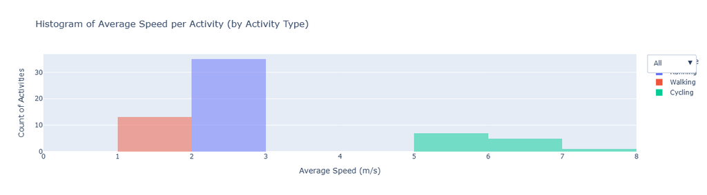

```python
import plotly.express as px
import pandas as pd

# --- Ensure we have one row per activity_id ---
df_unique = df[['activity_id', 'avg_speed_m_s', 'activity_type']].drop_duplicates()

df_unique = df_unique.rename(columns={'avg_speed_m_s': 'speed'})

#num_bins = df_unique['activity_id'].nunique()

num_bins = 10

# Unique activity types
activity_types = df_unique['activity_type'].unique()

# --- Create initial histogram (all activity types) ---
fig = px.histogram(
    df_unique,
    x='speed',
    color='activity_type',
    nbins=num_bins,
    barmode='overlay',
    title='Histogram of Average Speed per Activity (by Activity Type)',
    labels={'speed': 'Average Speed (m/s)'}
)

# --- Dropdown buttons ---
buttons = []

for activity in activity_types:
    visible = [trace.name == activity for trace in fig.data]   # match trace names

    buttons.append(
        dict(
            method="update",
            label=activity,
            args=[
                {"visible": visible},
                {"title": f"Histogram of Average Speed: {activity}"}
            ]
        )
    )

# Add "All" option
buttons.insert(0,
    dict(
        method="update",
        label="All",
        args=[
            {"visible": [True] * len(fig.data)},
            {"title": "Histogram of Average Speed per Activity (by Activity Type)"}
        ]
    )
)

fig.update_layout(
    updatemenus=[
        dict(
            active=0,
            buttons=buttons,
            x=1.1,
            y=1,
            xanchor="right",
            yanchor="top"
        )
    ],
    xaxis_title="Average Speed (m/s)",
    yaxis_title="Count of Activities"   # <-- now correct meaning
)

# Fix the axes so they never rescale
fig.update_xaxes(range=[0, 8])


fig.show()
```

Identify which activities had the highest heart rates. PERFECT DO NOT TOUCH

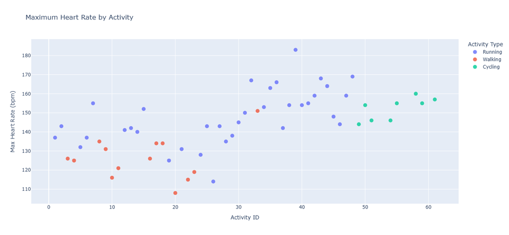

```python
import plotly.express as px

# --- 1️⃣ Compute max heart rate per activity ---
max_hr_df = (
    df.groupby('activity_id')['heart_rate']
      .max()
      .reset_index(name='heart_rate_max')
)

# --- 2️⃣ Merge activity_type into max_hr_df (if not already present) ---
if 'activity_type' in df.columns:
    activity_type_df = df[['activity_id', 'activity_type']].drop_duplicates()
    max_hr_df = max_hr_df.merge(activity_type_df, on='activity_id', how='left')
else:
    print("⚠️ Warning: activity_type not found in df. Colors will not be applied.")


# --- 3️⃣ Plotting function ---
def hover_max_heart_rate(df, title='Maximum Heart Rate by Activity'):

    df_plot = df.reset_index(drop=True)

    fig = px.scatter(
        df_plot,
        x='activity_id',
        y='heart_rate_max',
        color='activity_type',              # ← NEW: color by activity type
        title=title,
        labels={
            'activity_id': 'Activity ID',
            'heart_rate_max': 'Max Heart Rate (bpm)',
            'activity_type': 'Activity Type'
        },
        hover_data={
            'activity_id': True,
            'heart_rate_max': True,
            'activity_type': True
        }
    )

    fig.update_traces(marker=dict(size=10, opacity=0.8))

    fig.update_layout(height=600)

    fig.show()


# --- 4️⃣ Generate the plot ---
hover_max_heart_rate(max_hr_df)
```

[figure not shown]

```python
import matplotlib.pyplot as plt
import pandas as pd
import numpy as np

# Prepare the heart rate distributions per activity_id
heart_rate_df = df.groupby('activity_id')['heart_rate'].apply(list)

# Map each activity_id to its activity_type
activity_types = df.groupby('activity_id')['activity_type'].first()

# Compute median heart rate for each activity_id
median_hr = heart_rate_df.apply(np.median)

# Sort activity_ids by median heart rate
heart_rate_df_sorted = heart_rate_df.loc[median_hr.sort_values().index]

# Optional: also keep the activity_type mapping in the same order
activity_types_sorted = activity_types.loc[heart_rate_df_sorted.index]

# Assign a color to each activity_type
unique_types = activity_types.unique()
colors = plt.cm.Set1(np.linspace(0, 1, len(unique_types)))  # choose distinct colors
color_map = dict(zip(unique_types, colors))
violin_colors = [color_map[activity_types[aid]] for aid in heart_rate_df.index]

# Plot function
def heart_rate_violin(Distributions, violin_colors, activity_ids, showmeans=False, showmedians=True):
    fig, ax = plt.subplots(figsize=(12, 6))

    # Create the violin plot
    violinplt = ax.violinplot(Distributions, showmeans=showmeans, showmedians=showmedians)

    # Color the violins
    for i, body in enumerate(violinplt['bodies']):
        body.set_facecolor(violin_colors[i])
        body.set_edgecolor(None)
        body.set_alpha(0.7)

    # Customize means and medians
    if showmeans:
        violinplt['cmeans'].set_color('yellow')
    if showmedians:
        violinplt['cmedians'].set_color('black')

    # Set x-axis labels
    ax.set_xticks(range(1, len(activity_ids) + 1))
    ax.set_xticklabels(activity_ids, rotation=45)
    ax.set_xlabel('Activity_Id')
    ax.set_ylabel('Heart Rate')
    ax.set_title('Heart Rate Distributions by Activity')

    # Add legend for activity_type
    for t, c in color_map.items():
        ax.scatter([], [], color=c, label=t)
    ax.legend(title='Activity Type')

    plt.tight_layout()
    plt.show()

# Call the function
heart_rate_violin(heart_rate_df_sorted, violin_colors, heart_rate_df_sorted.index)
```

```python
Now for the final visualization: a 3D plot of one activity showing lat, long, alt and color coded by heart_rate
```

```python
df = clean_gps_data(df)

mapping_df = df
```

[output not shown]

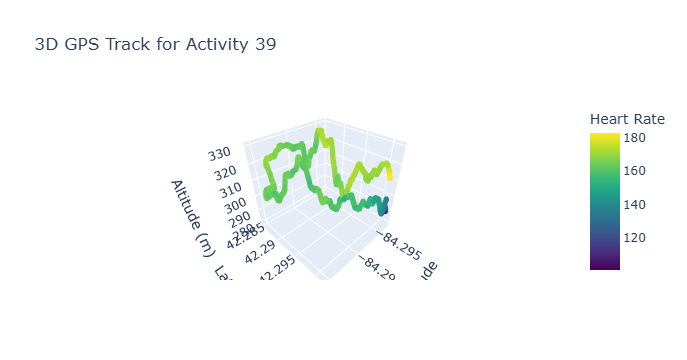

```python
import plotly.graph_objects as go

# Filter to one activity_id
aid = 39   # e.g., 123456
df_a = df[df["activity_id"] == aid].copy()

df_a = df_a.dropna(subset=["position_long_degrees", "position_lat_degrees", "enhanced_alt_int", "heart_rate"])

fig = go.Figure(data=go.Scatter3d(
    x=df_a["position_long_degrees"],
    y=df_a["position_lat_degrees"],
    z=df_a["enhanced_alt_int"],
    mode='markers',
    marker=dict(
        size=3,
        color=df_a["heart_rate"],     # color by heart rate
        colorscale='Viridis',         # or 'Turbo', 'Jet', etc.
        colorbar_title='Heart Rate',
    )
))

fig.update_layout(
    title=f"3D GPS Track for Activity {aid}",
    scene=dict(
        xaxis_title="Longitude",
        yaxis_title="Latitude",
        zaxis_title="Altitude (m)"
    )
)

fig.show()
```

```python
3D plot with slider for Activity_ID
```

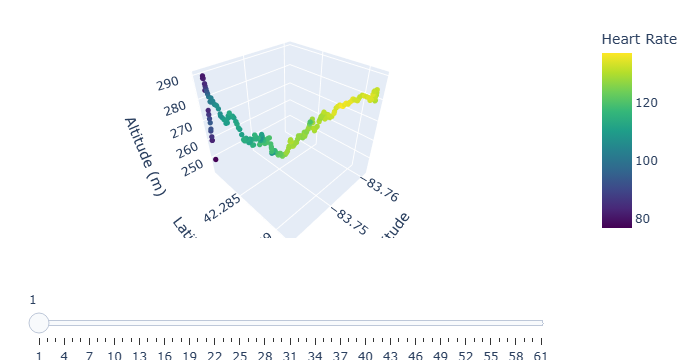

```python
import plotly.graph_objects as go
import numpy as np

# Get all activity_ids
activity_ids = sorted(df["activity_id"].unique())

# Build frames (one per activity)
frames = []
for aid in activity_ids:
    df_a = df[df["activity_id"] == aid].dropna(subset=[
        "position_long_degrees", "position_lat_degrees", "enhanced_alt_int", "heart_rate"
    ])

    frames.append(
        go.Frame(
            name=str(aid),
            data=[
                go.Scatter3d(
                    x=df_a["position_long_degrees"],
                    y=df_a["position_lat_degrees"],
                    z=df_a["enhanced_alt_int"],
                    mode='markers',
                    marker=dict(
                        size=3,
                        color=df_a["heart_rate"],
                        colorscale='Viridis',     # KEEPING THIS EXACTLY
                        colorbar_title='Heart Rate'
                    )
                )
            ]
        )
    )

# --- Initial frame (first activity_id) ---
df0 = df[df["activity_id"] == activity_ids[0]].dropna(subset=[
    "position_long_degrees", "position_lat_degrees", "enhanced_alt_int", "heart_rate"
])

fig = go.Figure(
    data=[
        go.Scatter3d(
            x=df0["position_long_degrees"],
            y=df0["position_lat_degrees"],
            z=df0["enhanced_alt_int"],
            mode='markers',
            marker=dict(
                size=3,
                color=df0["heart_rate"],
                colorscale='Viridis',
                colorbar_title='Heart Rate'
            )
        )
    ],
    frames=frames
)

# --- Slider ---
fig.update_layout(
    sliders=[
        {
            "steps": [
                {
                    "args": [[str(aid)], {"frame": {"duration": 0}, "mode": "immediate"}],
                    "label": str(aid),
                    "method": "animate"
                }
                for aid in activity_ids
            ],
            "transition": {"duration": 0},
            "pad": {"t": 50},
            "len": 0.9,
            "x": 0.05,
            "y": 0
        }
    ],
    scene=dict(
        title=f"3D GPS Track for Activity {aid}",
        xaxis_title="Longitude",
        yaxis_title="Latitude",
        zaxis_title="Altitude (m)"
    )
)

# --- Reduce Margins ---
fig.update_layout(
    margin=dict(l=0, r=0, t=20, b=20)
)

fig.show()
```

```python
For Activity ID 39 (highest heartrate), map lat, long and alt
```

```python
# From mpl_toolkits.mplot3d import Axes3D

# Fig = plt.figure()
# Ax = fig.gca(projection='3d')

# #sends x, y, and z numbers to map
# artists=ax.scatter(df[['position_long_degrees'], df['position_lat_degrees_mercantor'],df['enhanced_altitude'], s=5, c=df['Power'], cmap=['Blues']])

# #pass the “artists” variable with location info in there into the colorbar
# plt.colorbar(artists).set_label('Power (watts)')

# ax.set_xlabel(‘Longitude’)
# ax.set_ylabel(‘Latitude’)
# ax.set_zlabel(‘Altitude’)
```

Make 3D plot of lat, long, alt, and heart rate. (or velocity).

```python
df.columns
```

[output not shown]

```python
3D Plot lat, long, alt, color coded by heart rate
```

```python
import pandas as pd
import plotly.express as px

df.columns()


fig = px.scatter_3d(
    df,
    x="position_long_degrees",
    y="position_lat_degrees",
    z="enhanced_alt_int",
    color="heart_rate",
    color_continuous_scale="Turbo",
    labels={
        "position_long_degrees": "Longitude",
        "position_lat_degrees": "Latitude",
        "enhanced_alt_int": "Altitude (m)",
        "heart_rate": "Heart Rate (bpm)"
    },
)

fig.update_traces(marker=dict(size=4))
fig.update_layout(title="3D Path Colored by Heart Rate")
fig.show()
```

[output not shown]

```python
Rule 5: Record dependencies
```

[output not shown]

```python
import pkgutil
import sys
import importlib

def list_imported_package_versions(print_results=True):
    """
    Finds all currently imported modules that are also installable packages,
    retrieves their versions, and returns a dictionary like:
        {package_name: version}

    Parameters
    ----------
    print_results : bool
        If True, prints the package==version lines.

    Returns
    -------
    dict
        Mapping of package names to version strings.
    """
    modules = {name for _, name, _ in pkgutil.iter_modules()}
    imports = {name for name in sys.modules.keys() if name in modules}

    versions = {}

    for m in sorted(imports):
        try:
            v = importlib.import_module(m).__version__
            versions[m] = v
            if print_results:
                print(f"{m}=={v}")
        except Exception:
            pass

    return versions
```

Rule 6: Use Version Control